# R Notebook

### Step 4: Variable Associations With The Response

```r
library(tidyverse)
train <- read_csv('C:/Users/Will/Documents/MSA/jobs/rti_challenge/data-scientist-exercise01/data/train.csv')

train %>%
  mutate_each(funs(factor(.)), -c(age:hours_week)) %>%
  mutate(over_50k = as.numeric(as.character(over_50k))) -> train
```

**Age**  
Relationship between the log odds of making over 50k and Age is not linear. The trend between age and and making over 50k is clearly defined.

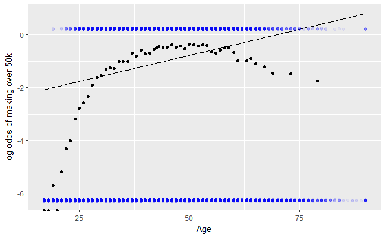

**Age**  
Here a third order polynomial of age is used to model whether a person is making over 50k or not

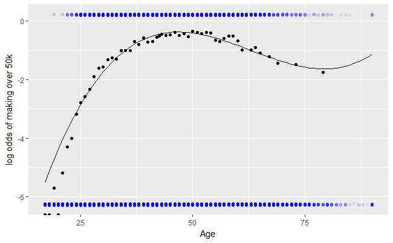

**education_num**  
The association between the log odds between making over 50k and education number appears to be linear, With the exception of the lower education levels.

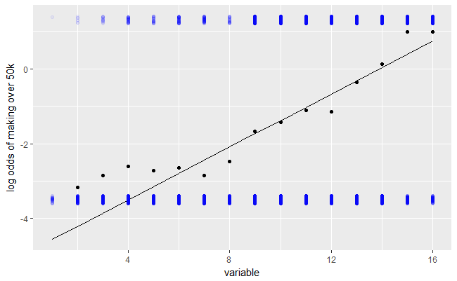

**education_num**  
With the exception of the lower education levels, there is an approximately linear relationship. To adjust for the lower education numbers, all values below 8 are combined into a single category. Now the line has a much better fit.

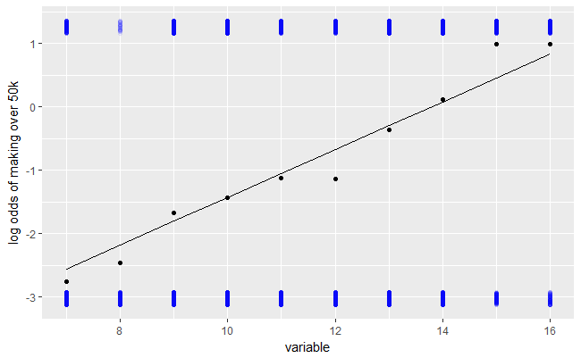

**capital_gain**  
This variable has an outlier at 99,999 that is causing some problems.

```
glm.fit: fitted probabilities numerically 0 or 1 occurred
```

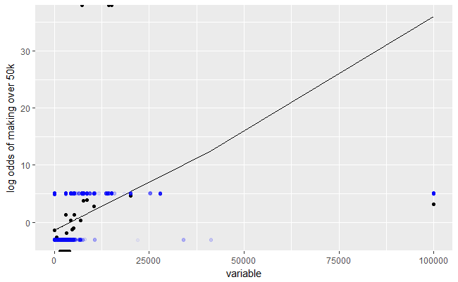

```r
plot_continuous(train$capital_gain , n = 100, response = train$over_50k, max_poly_degree = 1, log_odds = T)
```

**capital_gain**  
In this plot, capital gain is log scaled and the variable is filtered so we are just looking at capital_gain values > 0. The y-axis is in a probability form instead of log-odds. It looks like there is great separation between capital gain and over_50k here.

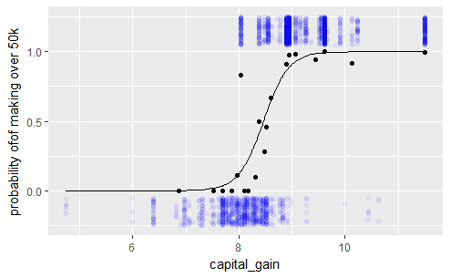

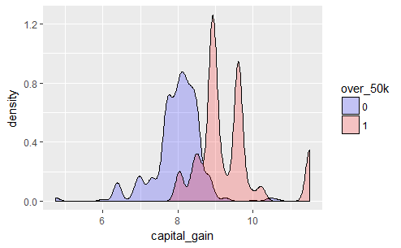

**capital_loss**  
There appears to be a week relationship between capital_loss and the reponse

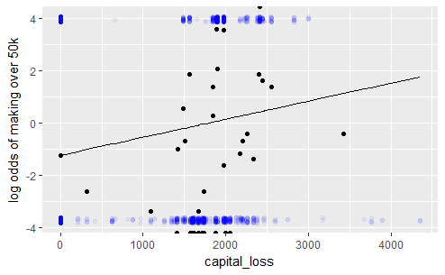

```r
plot_continuous(train$capital_loss, n = 30, response = train$over_50k, max_poly_degree = 1, log_odds = T, variable_name = 'capital_loss')
```

**capital_loss**  
It looks like the important distinction between this variable is that at 0, it is more likely to make less than 50k. Greater than 0 it is more likely to make 50k. Next I’ll filter out the zeros so I can better see the middle distribtion

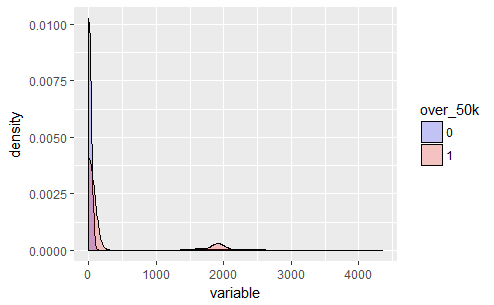

**capital_loss**  
After filtering out the zeros, There really is not much separation here. Instead I’ll convert this variable to be categorical. 0 if equal to 0, and 1 if greater than 0

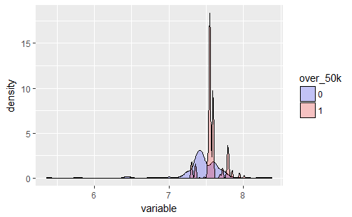

```r
train %>%
  filter(capital_loss > 0) -> train2
plot_density(log(train2$capital_loss + 1), response = train2$over_50k)
```

**hours_week**

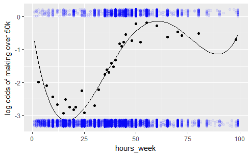

```r
plot_continuous(train$hours_week, n = 200, response = train$over_50k, max_poly_degree = 4, log_odds = T, variable_name = 'hours_week')
```